# 随机森林回归 Random Forest Regression

## 绘制交叉验证曲线

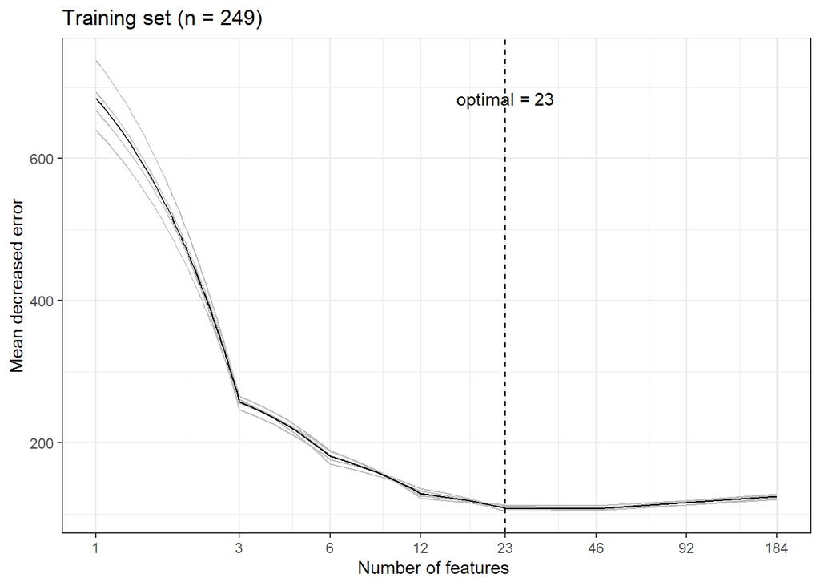

```r
# 提取x轴标签
n.var = error.cv0$num
# 提取y轴数据+标签
error.cv = error.cv0[,2:6]
colnames(error.cv) = paste('err',1:5,sep='.')
# 添加均值
err.mean = apply(error.cv,1,mean)
# 合并新的数据库，x+error+mean
allerr = data.frame(num=n.var,err.mean=err.mean,error.cv)
# number of otus selected 人为在图中观察的结果，30几乎为最低，且数量可接受
optimal = 23

# 图1：机器学习结果交叉验证图，选择Top features
# 图中 + 5条灰色拆线+1条黑色均值拆线+一条最优垂线+X轴对数变换
write.table(allerr, file = "rfcv.txt", sep = "\t", quote = F, row.names = T, col.names = T)

p = ggplot() + # 开始绘图
  geom_line(aes(x = allerr$num, y = allerr$err.1), colour = 'grey') + # 5次验证灰线
  geom_line(aes(x = allerr$num, y = allerr$err.2), colour = 'grey') +
  geom_line(aes(x = allerr$num, y = allerr$err.3), colour = 'grey') +
  geom_line(aes(x = allerr$num, y = allerr$err.4), colour = 'grey') +
  geom_line(aes(x = allerr$num, y = allerr$err.5), colour = 'grey') +
  geom_line(aes(x = allerr$num, y = allerr$err.mean), colour = 'black') + # 均值黑线
  geom_vline(xintercept = optimal, colour='black', lwd=0.36, linetype="dashed") + # 最优垂线
  coord_trans(x = "log2") + # X轴对数变换和刻度
  scale_x_continuous(breaks = sort(error.cv0$num)) + # , max(allerr$num)
  labs(title=paste('Training set (n = ', dim(t(sub_otu))[1],')', sep = ''),
       x='Number of features ', y='Mean decreased error') +
  annotate("text", x = optimal, y = max(allerr$err.mean), label=paste("optimal = ", optimal, sep="")) + theme_bw()
p
```

```r
ggsave(p, file = "rfcv.pdf", width = 89, height = 59, unit = 'mm')
```

## 导出feature重要性

根据验证验证，预览和保存feature贡献度

```r
imp= as.data.frame(rf$importance)
imp = imp[order(imp[,1],decreasing = T),]
head(imp,n=10)
```

|  | %IncMSE | IncNodePurity |
| --- | --- | --- |
| k__Bacteria;p__Proteobacteria;c__Deltaproteobacteria | 272.69065 | 64575.923 |
| k__Bacteria;p__[Thermi];c__Deinococci | 218.99135 | 40720.493 |
| k__Bacteria;p__Spirochaetes;c__[Leptospirae] | 215.58015 | 45753.705 |
| k__Bacteria;p__Verrucomicrobia;c__Verrucomicrobiae | 103.57790 | 21457.344 |
| k__Bacteria;p__Nitrospirae;c__Nitrospira | 100.18003 | 25644.621 |
| k__Bacteria;p__Chlorobi;c__unknown1930 | 82.61664 | 26978.199 |
| k__Bacteria;p__Gemmatimonadetes;c__Gemmatimonadetes | 77.42131 | 13527.075 |
| k__Bacteria;p__Bacteroidetes;c__[Saprospirae] | 37.52255 | 6248.673 |
| k__Bacteria;p__Firmicutes;c__Clostridia | 34.65399 | 6721.578 |
| k__Bacteria;p__Fibrobacteres;c__Fibrobacteria | 34.40051 | 6674.054 |

```r
write.table(imp,file = "importance_class.txt",quote = F,sep = '\t', row.names = T, col.names = T)
# 简单可视化
# varImpPlot(rf, main = "Top 10 - Feature OTU importance",n.var = 9, bg = par("bg"),
#            color = par("fg"), gcolor = par("fg"), lcolor = "gray" )
```

## ggplot2美化feature贡献度

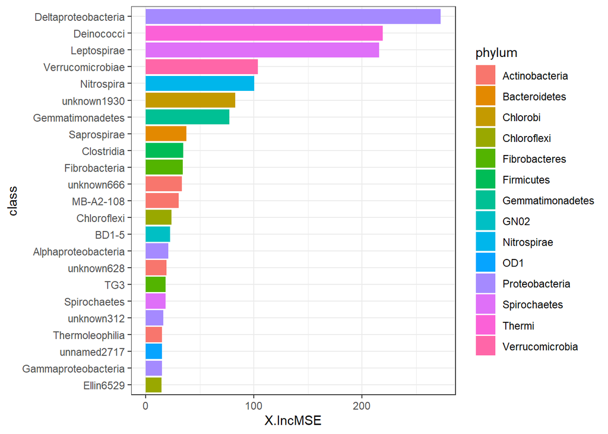

```r
# 读取所有feature贡献度
imp = read.table("importance_class.txt", header=T, row.names= 1, sep="\t")
# 分析选择top23分组效果最好
imp = head(imp, n=23)
# 反向排序X轴，让柱状图从上往下画
imp = imp[order(1:23,decreasing = T),]

# imp物种名分解，提纲作为名称，门作为注释
# 去除公共部分
imp$temp = gsub("k__Bacteria;p__","",rownames(imp),perl=TRUE)
# 提取门名称
# 删除；后面的内容
imp$phylum = gsub(";.+","",imp$temp, perl=TRUE)
# 删除带中括号的名称
imp$phylum = gsub("[\\[\\]]+","",imp$phylum,perl=TRUE)
# 提取纲名称
imp$class = gsub("[\\w\\[\\];_]+;c__","",imp$temp,perl=TRUE)
imp$class = gsub("[\\[\\]]+","",imp$class,perl=TRUE)
# 添加纲level保持队形
imp$class=factor(imp$class,levels = imp$class)

# 图1. 绘制物种类型种重要性柱状图
library(ggplot2)
p=ggplot(data = imp, mapping = aes(x=class,y=X.IncMSE,fill=phylum)) +
  geom_bar(stat="identity")+coord_flip()+theme_bw()
p
```

```r
ggsave(paste("rf_imp_feature",".pdf", sep=""), p, width = 8, height =4)
```

# 时间序列展示Features热图

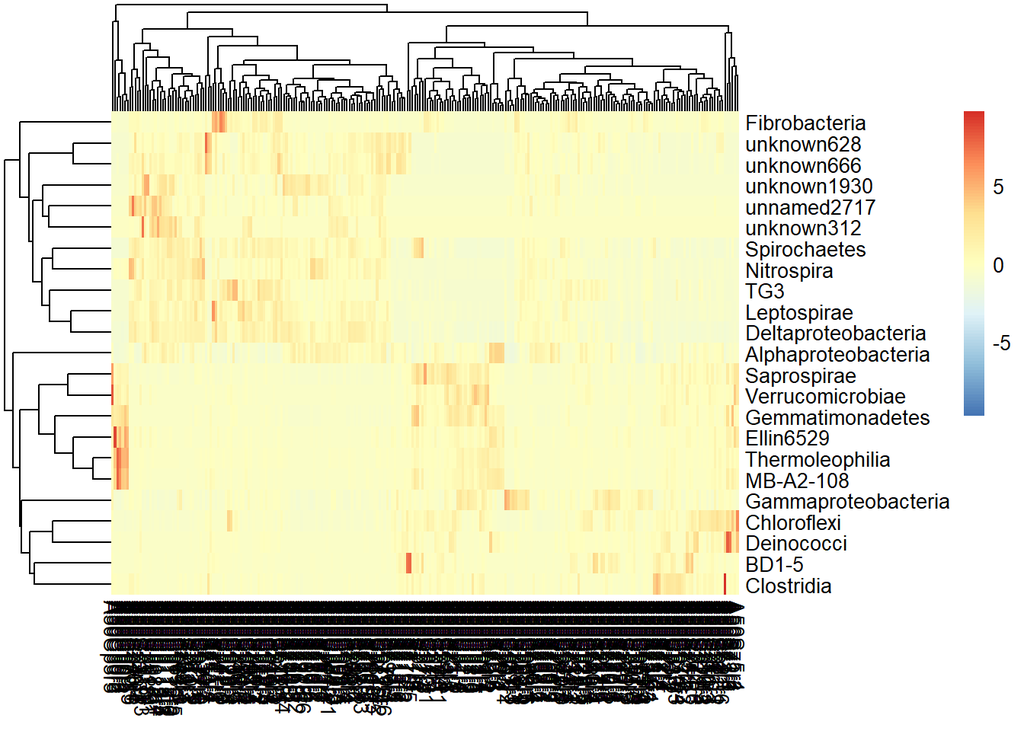

```r
# 加载热图绘制包
library(pheatmap)
# 数据筛选23个feature展示
sub_abu = sub_otu[rownames(imp),]
# 简化行名
rownames(sub_abu) = imp$class

# 直接自动聚类出图
pheatmap(sub_abu, scale = "row")
```

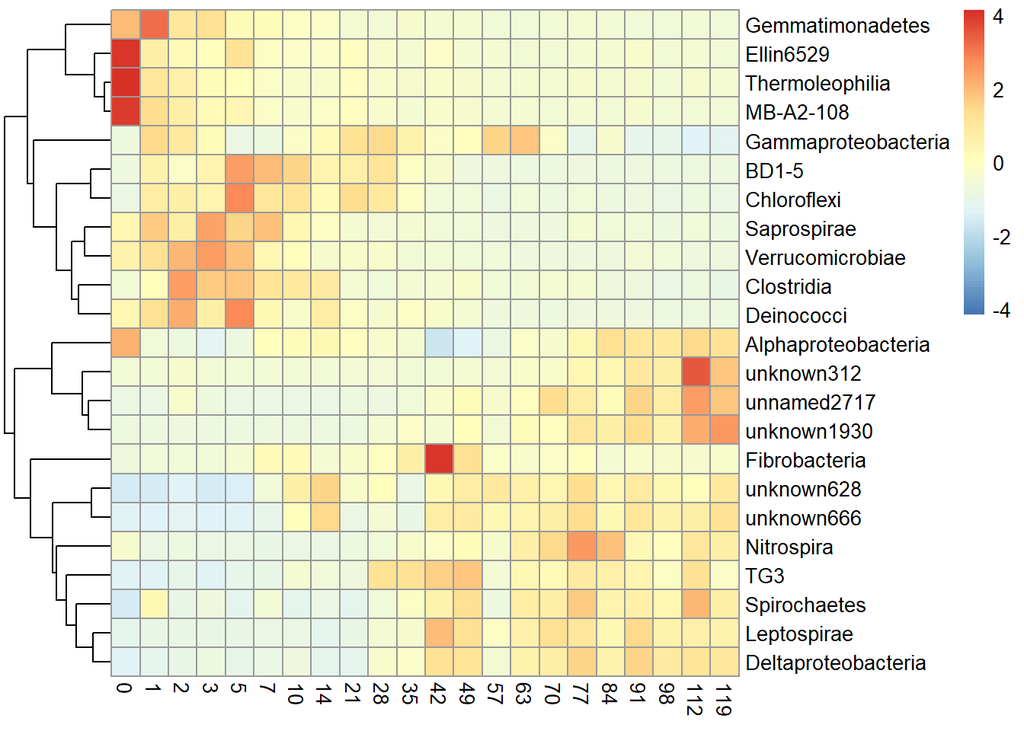

```r
# 按时间为组合并均值
sampFile = as.data.frame(sub_map$day2,row.names = row.names(sub_map))
colnames(sampFile)[1] = "group"
mat_t = t(sub_abu)
mat_t2 = merge(sampFile, mat_t, by="row.names")
mat_t2 = mat_t2[,-1]
mat_mean = aggregate(mat_t2[,-1], by=mat_t2[1], FUN=mean) # mean
otu_norm_group = do.call(rbind, mat_mean)[-1,]
colnames(otu_norm_group) = mat_mean$group
pheatmap(otu_norm_group,scale="row",cluster_cols = F, cluster_rows = T)
```

```r
pheatmap(otu_norm_group, scale = "row", filename = "heatmap_groups.pdf", width = 5, height = 5)
```

## 模型预测效率

基于训练集相关性评估

```r
# 模型评估
train.p = predict(rf, type = "response")
df = data.frame(observed = sub_map$day, predict = train.p)
# 保存预测结果与真实结果比较
write.table(df,file = "train_predict.txt",quote = F,sep = '\t', row.names = T, col.names = T)
cor = cor.test(df[,1], df[,2], method = "spearman") # spearman or pearson
```

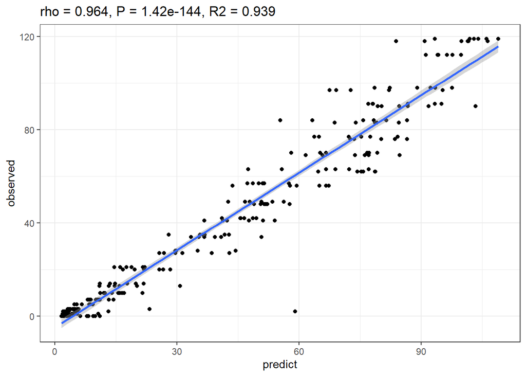

```r
m = lm(observed ~ predict, df)

p = ggplot(df, aes(predict, observed)) +
  geom_point() +
  geom_smooth(method = "lm") +
  labs(title = paste("rho = " , round(cor$estimate, digits = 3), ", P = " , signif(cor$p.value, digits = 3), ", R2 = ", round(summary(m)$r.squared, digits = 3) , sep = "")) +
  theme_bw()
p
```

```r
ggsave(paste("train_predict.pdf", sep=""), p, width = 4, height = 2.5)
```

基于测序集评估模型普适性

```r
## 预测验证集
test_map = tc_map[tc_map$genotype %in% c("IR24"),]
# 筛选OTU
idx = rownames(test_map) %in% colnames(otu_table)
test_map = test_map[idx,]
test_otu = otu_table[, rownames(test_map)]

test.p = predict(rf, t(test_otu), type = "response")

df = data.frame(observed = test_map$day, predict = test.p)
# 保存预测结果与真实结果比较
write.table(df,file = "test_predict.txt",quote = F,sep = '\t', row.names = T, col.names = T)

cor = cor.test(df[,1], df[,2], method = "spearman")
```

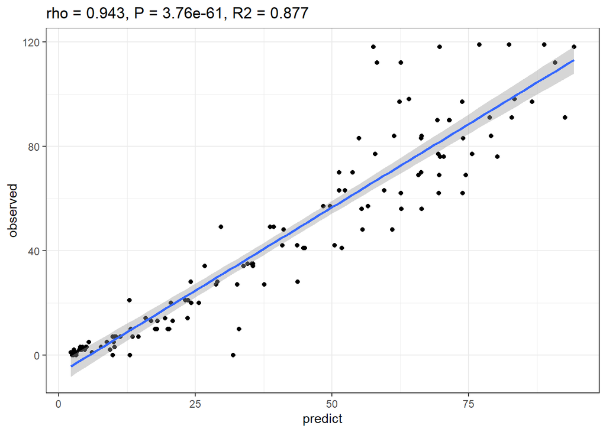

```r
m = lm(observed ~ predict, df)

p = ggplot(df, aes(predict, observed)) +
  geom_point() +
  geom_smooth(method = "lm") +
  labs(title = paste("rho = " , round(cor$estimate, digits = 3), ", P = " , signif(cor$p.value, digits = 3), ", R2 = ", round(summary(m)$r.squared, digits = 3) , sep = "")) +
  theme_bw()
p
```

```r
ggsave(paste("test_predict.pdf", sep=""), p, width = 4, height = 2.5)
```

使用此脚本，请引用下文：

If used this script, please cited:

**Yong-Xin Liu**, Lei Chen, Tengfei Ma, Xiaofang Li, Maosheng Zheng, Xin Zhou, Liang Chen, Xubo Qian, Jiao Xi, Hongye Lu, Huiluo Cao, Xiaoya Ma, Bian Bian, Pengfan Zhang, Jiqiu Wu, Ren-You Gan, Baolei Jia, Linyang Sun, Zhicheng Ju, Yunyun Gao, **Tao Wen**, **Tong Chen**. 2023. EasyAmplicon: An easy-to-use, open-source, reproducible, and community-based pipeline for amplicon data analysis in microbiome research. **iMeta** 2: e83. https://doi.org/10.1002/imt2.83

数据来源：

Data source:

Jingying Zhang, Na Zhang, Yong-Xin Liu, Xiaoning Zhang, Bin Hu, Yuan Qin, Haoran Xu, Hui Wang, Xiaoxuan Guo, Jingmei Qian, Wei Wang, Pengfan Zhang, Tao Jin, Chengcai Chu, Yang Bai. 2018. Root microbiota shift in rice correlates with resident time in the field and developmental stage. Science China Life Sciences 61: 613-621. https://doi.org/10.1007/s11427-018-9284-4

Copyright 2016-2023 Yong-Xin Liu liuyongxin@caas.cn, Tao Wen taowen@njau.edu.cn, Tong Chen chent@nrc.ac.cn